# Housing Cri.. Prices

## 2.4 Feature Dependencies

Some features’ values heavily depend on the value of another feature. For example the values of $BsmtUnfSF$, $TotalBsmtSF$ only make sense if features $BsmtCond$, $BsmtExposure$, $BsmtQual$ are not $noBasement$. This information is given in *data_description*.

$$\begin{aligned}
BsmtUnfSF, TotalBsmtSF : BsmtCond, BsmtExposure, BsmtQual \ne noBasement\\
BsmtFinSF1 : BsmtFinType1 \ne noBasement\\
BsmtFinSF2 : BsmtFinType2 \ne noBasement \\
GarageYrBlt, GarageCars, GarageArea: GarageType, GarageFinish, GarageQual,
GarageCond \ne noGarage \\
PoolArea : PoolQC \ne noPool \\
MiscVal : MiscFeature \ne none \\
MasVnrArea : MasVnrType \ne none
\end{aligned}$$
For the garage and basement features there are several features which indicate the absence of that feature. If one of them indicates the absence of a feature, the others should too.

```r
setdiff(which(full$BsmtCond == "noBasement"),
          which(full$BsmtExposure == "noBasement"))
```

```
## [1] 2041 2186 2525
```

```r
setdiff(which(full$BsmtCond == "noBasement"),
          which(full$BsmtQual == "noBasement"))
```

```
## [1] 2041 2186 2525
```

```r
full[c(2041, 2186, 2525), .(Id, BsmtCond, BsmtExposure, BsmtQual,
                            BsmtUnfSF, TotalBsmtSF)]
```

```
##      Id   BsmtCond BsmtExposure BsmtQual BsmtUnfSF TotalBsmtSF
## 1: 2041 noBasement           Mn       Gd         0        1426
## 2: 2186 noBasement           No       TA        94        1127
## 3: 2525 noBasement           Av       TA       240         995
```

So here the *data_description* is not consistent. The general condition is set to *noBasement* but there are values for basement exposure, quality, and so on.

```r
setdiff(which(full$GarageType == "noGarage"),
          which(full$GarageFinish == "noGarage"))
```

```
## integer(0)
```

```r
setdiff(which(full$GarageType == "noGarage"),
          which(full$GarageQual == "noGarage"))
```

```
## integer(0)
```

```r
setdiff(which(full$GarageType == "noGarage"),
          which(full$GarageCond == "noGarage"))
```

```
## integer(0)
```

The garage features doesn’t have these inconsistencies.

```r
featDeps <- list(
  BsmtCond = c("BsmtUnfSF", "TotalBsmtSF"),
  BsmtFinType1 = "BsmtFinSF1",
  BsmtFinType2 = "BsmtFinSF2",
  GarageType = c("GarageYrBlt", "GarageCars", "GarageArea"),
  PoolQC = "PoolArea",
  MiscFeature = "MiscVal",
  MasVnrType = "MasVnrArea"
)
```

## 2.5 Missing Data

$NA$ which are left must be true missing data. The following table gives a complete summary of missing data.

```r
naFeats <- vapply(
  colnames(full),
  function(j) any(is.na(full[[j]])) || any(full[[j]] == ""),
  logical(1)
)
md.pattern(full[, colnames(full)[naFeats], with = FALSE])
```

```
##      Exterior1st Exterior2nd BsmtFinSF1 BsmtFinSF2 BsmtUnfSF TotalBsmtSF
## 1030           1           1          1          1         1           1
##  240           1           1          1          1         1           1
##   90           1           1          1          1         1           1
##    1           1           1          1          1         1           1
##   49           1           1          1          1         1           1
## 1044           1           1          1          1         1           1
##   10           1           1          1          1         1           1
##    6           1           1          1          1         1           1
##    6           1           1          1          1         1           1
##   25           1           1          1          1         1           1
##    1           1           1          1          1         1           1
##  203           1           1          1          1         1           1
##   95           1           1          1          1         1           1
##    1           1           1          1          1         1           1
```

[output cut: 129 more lines]

The total number of missing values per feature will be saved. The features with at least one missing value are shown below.

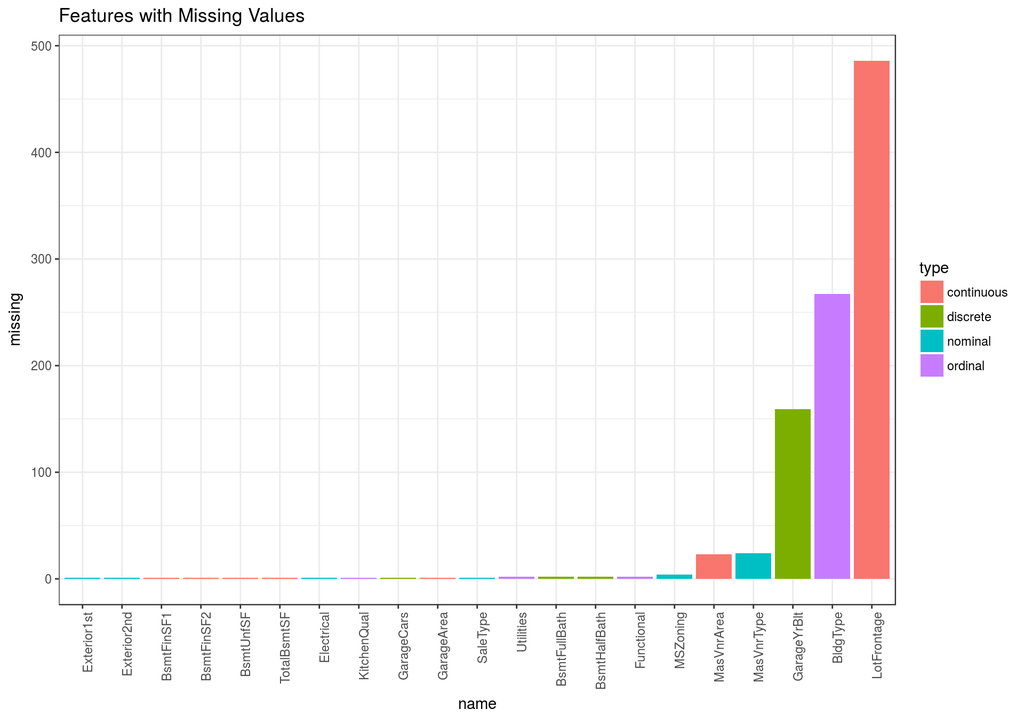

```r
mdpat <- md.pattern(full[, -ncol(train), with = FALSE])
total <- mdpat[nrow(mdpat), -ncol(mdpat)]
featAttr$missing <- total[match(featAttr$name, names(total))]
dt <- featAttr[missing > 0, ]
dt$name <- factor(dt$name, levels = dt$name[order(dt$missing)])
ggplot(dt, aes(x = name, y = missing, fill = type)) +
  geom_bar(stat = "identity") +
  theme_bw() +
  theme(axis.text.x = element_text(angle = 90, hjust = 1)) +
  ggtitle("Features with Missing Values")
```

# 3 Feature Exploration

## 3.1 Continuous and Discrete Features

### 3.1.1 Feature Distributions

The following table gives a descriptive overview about continuous and discrete feature distributions. Besides the range and averages of variables, the relative difference between mean and median is given as an indicator of the skewness. In addition the relative cardinality and the abundance of outliers are given.

```r
m <- apply(full[, c(contVars, discVars), with = FALSE], 2,
      function(j) summary(j)[c(1, 3, 4, 6)])
cards <- apply(full[, c(contVars, discVars), with = FALSE], 2,
               function(j) length(unique(j)) / length(j))
outs <- apply(full[, c(contVars, discVars), with = FALSE], 2,
              function(j) length(boxplot.stats(j)$out) / length(j))
dt <- data.table(t(m))
dt$relDelta <- round((dt$Mean - dt$Median) / dt$Mean, 2)
dt$relCard <- round(cards, 2)
dt$relOuts <- round(outs, 2)
rownames(dt) <- c(contVars, discVars)
dt$type <- rep(c("cont", "disc"), c(length(contVars), length(discVars)))
DT::datatable(dt, options = list(dom = "t", pageLength = 40)) %>%
  formatStyle(
    'relDelta',
    color = styleInterval(c(0.2, 0.8), c('green', 'orange', 'red'))
  ) %>%
  formatStyle(
    'relCard',
    color = styleInterval(c(0.2, 0.6), c('red', 'orange', 'green'))
  ) %>%
  formatStyle(
    'relOuts',
    color = styleInterval(c(0.05, 0.1), c('green', 'orange', 'red'))
  ) %>%
  formatStyle(
    'type',
    color = styleEqual(unique(dt$type), c('orange', 'blue'))
  )
```

|  | Min. | Median | Mean | Max. | relDelta | relCard | relOuts | type |
| --- | --- | --- | --- | --- | --- | --- | --- | --- |
| LotArea | 1300 | 9453 | 10170 | 215200 | 0.07 | 0.67 | 0.04 | cont |
| MasVnrArea | 0 | 0 | 102.2 | 1600 | 1 | 0.15 | 0.07 | cont |
| BsmtFinSF1 | 0 | 368.5 | 441.4 | 5644 | 0.17 | 0.34 | 0.01 | cont |
| BsmtFinSF2 | 0 | 0 | 49.58 | 1526 | 1 | 0.09 | 0.12 | cont |
| BsmtUnfSF | 0 | 467 | 560.8 | 2336 | 0.17 | 0.39 | 0.02 | cont |
| TotalBsmtSF | 0 | 989.5 | 1052 | 6110 | 0.06 | 0.36 | 0.04 | cont |
| X1stFlrSF | 334 | 1082 | 1160 | 5095 | 0.07 | 0.37 | 0.01 | cont |
| X2ndFlrSF | 0 | 0 | 336.5 | 2065 | 1 | 0.22 | 0 | cont |
| LowQualFinSF | 0 | 0 | 4.694 | 1064 | 1 | 0.01 | 0.01 | cont |
| GrLivArea | 334 | 1444 | 1501 | 5642 | 0.04 | 0.44 | 0.03 | cont |

[output cut: 22 more lines]

In *GarageYrBlt* the maximum value is 2207, which does not make sense. It seems that this is a type and the real value is 2007. After checking that there are not more values above 2010 2207 is changed to 2007.

```r
full[GarageYrBlt == 2207, GarageYrBlt := 2007]
```

There are a lot of continuous features with low cardinality and a high difference between mean and median. All these variables have a median of 0. Some of these variables are dependent on other categorical variables, so it is plausible that they are sparse.

### 3.1.2 Correlatio between Features

The Pearson Correlation Coefficient is calculated for all feature pairs where both features are discrete or continous. The results are shown as heatmap below. Using euclidean distance of the correlation matrix as a metric rows and columns were hierarchically ordered (complete link).

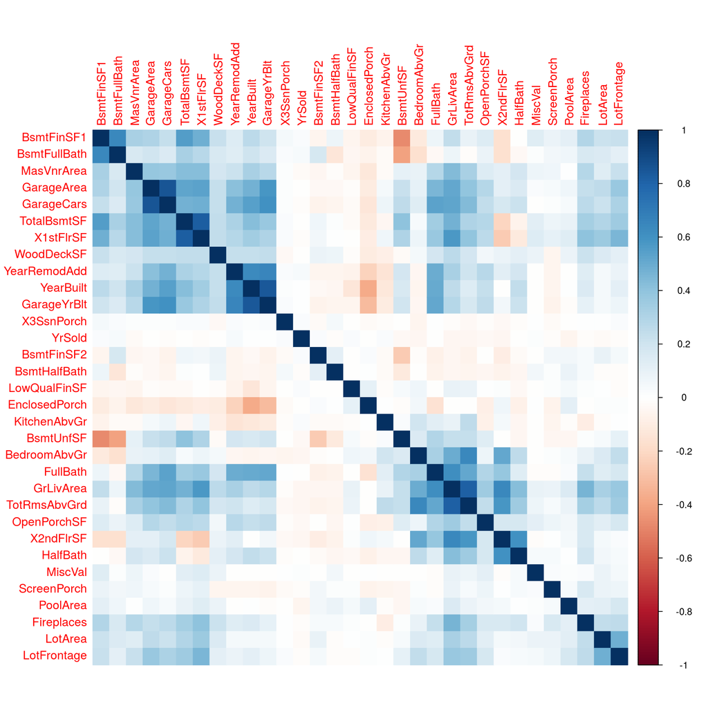

```r
m <- cor(
  full[, c(contVars, discVars), with = FALSE],
  use = "complete.obs"
)
corrplot(m, method = "color", order = "hclust")
```

Some clusters are visible. The same hierarchical clustering is shown as tree below.

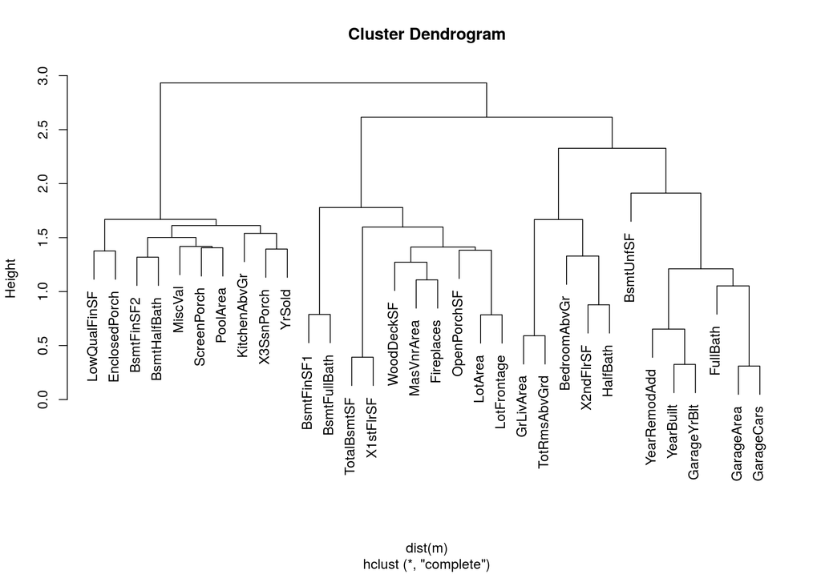

```r
corrClust <- hclust(dist(m))
plot(corrClust)
```

### 3.1.3 Correlation to Target

For all continuous and discrete features the pearson correlation coefficient to the target *SalePrice* is calculated. Results are ordered by correlation. The color labels the feature type, continuous or discrete.

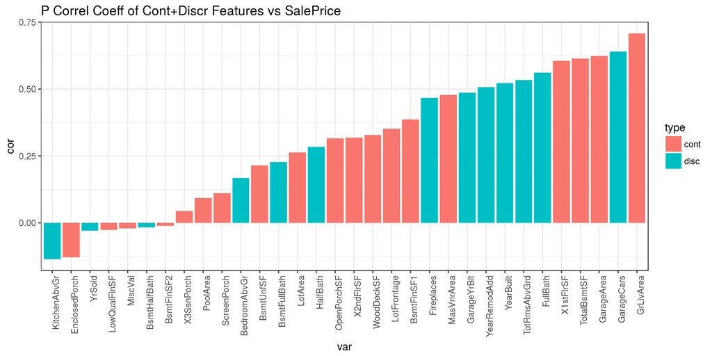

```r
train <- full[label == "train", !"label", with = FALSE]
cors <- vapply(
  c(contVars, discVars),
  function(i) cor(train[[i]], train$SalePrice, use = "complete.obs"),
  numeric(1)
)
df <- data.frame(
  var = factor(c(contVars, discVars),
               levels = c(contVars, discVars)[order(cors)]),
  cor = cors,
  type = rep(c("cont", "disc"), c(length(contVars), length(discVars)))
)
ggplot(df, aes(x = var, y = cor, fill = type)) +
  geom_bar(stat = "identity") +
  theme_bw() +
  theme(axis.text.x = element_text(angle = 90, hjust = 1)) +
  ggtitle("P Correl Coeff of Cont+Discr Features vs SalePrice")
```

## 3.2 Categorical Features

### 3.2.1 Feature Distributions

As an overview of nominal and ordinal features their categorical distribution is described. The table below summarizes range and averages, as well as the relative difference between mean and median (*relDalta*).

```r
m <- apply(full[, c(ordVars, nomVars), with = FALSE], 2,
           function(j) summary(as.vector(table(j)))[c(1, 3, 4, 6)])
dt <- data.table(t(m))
dt$relDelta <- round((dt$Mean - dt$Median) / dt$Mean, 2)
dt$type <- rep(c("ord", "nom"), c(length(ordVars), length(nomVars)))
rownames(dt) <- c(ordVars, nomVars)
DT::datatable(dt, options = list(dom = "t", pageLength = 40)) %>%
  formatStyle(
    'relDelta',
    color = styleInterval(c(0.2, 0.8), c('green', 'orange', 'red'))
  ) %>%
  formatStyle(
    'type',
    color = styleEqual(unique(dt$type), c('orange', 'blue'))
  )
```

|  | Min. | Median | Mean | Max. | relDelta | type |
| --- | --- | --- | --- | --- | --- | --- |
| MSSubClass | 1 | 113.5 | 182.4 | 1079 | 0.38 | ord |
| LotShape | 16 | 522 | 729.8 | 1859 | 0.28 | ord |
| Utilities | 1 | 1458 | 1458 | 2916 | 0 | ord |
| LandSlope | 16 | 125 | 973 | 2778 | 0.87 | ord |
| BldgType | 227 | 1326 | 1326 | 2425 | 0 | ord |
| OverallQual | 4 | 166.5 | 291.9 | 825 | 0.43 | ord |
| OverallCond | 7 | 101 | 324.3 | 1645 | 0.69 | ord |
| ExterQual | 35 | 543 | 729.8 | 1798 | 0.26 | ord |
| ExterCond | 3 | 67 | 583.8 | 2538 | 0.89 | ord |
| BsmtQual | 81 | 258 | 583.8 | 1283 | 0.56 | ord |

[output cut: 37 more lines]

For most variables there is a big difference in the frequency of classes that can occur. There is no feature where a class can be completely excluded, but there are some features which have classes with only one representation.

### 3.2.2 Correlation between Features

The Cramer’s V is calculated for all feature pairs where both features are categories. The results are shown as heatmap below. Using euclidean distance of the correlation matrix as a metric rows and columns were hierarchically ordered (complete link).

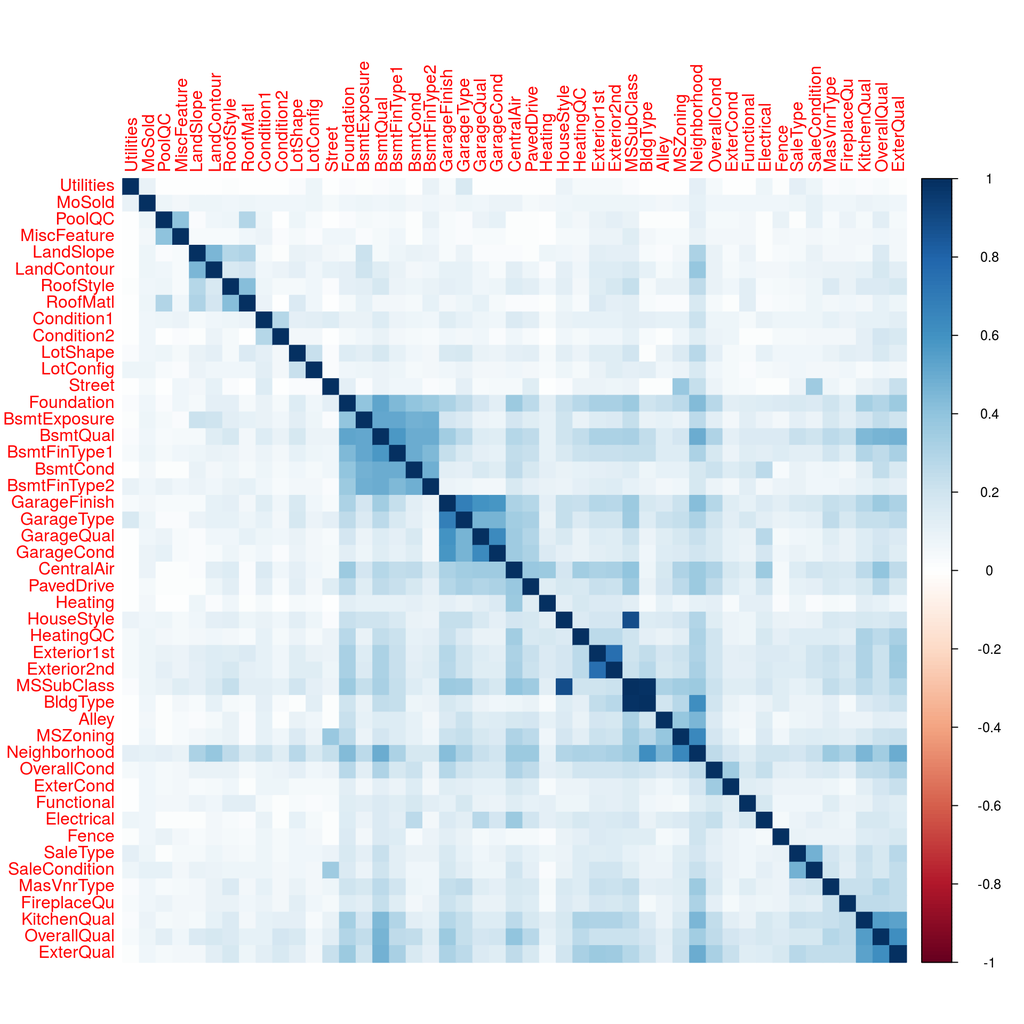

```r
m <- as.matrix(full[, c(ordVars, nomVars), with = FALSE])
m <- m[complete.cases(m), ]
mCramer <- vapply(
  seq_len(ncol(m)),
  function(i) {
    vapply(
      seq_len(ncol(m)),
      function(j) {
        assocstats(table(m[, i], m[, j]))$cramer
      },
      numeric(1)
    )
  },
  numeric(ncol(m))
)
colnames(mCramer) <- colnames(m)
rownames(mCramer) <- colnames(m)
corrplot(mCramer, method = "color", order = "hclust")
```

The same hierarchical clustering is shown as tree below.

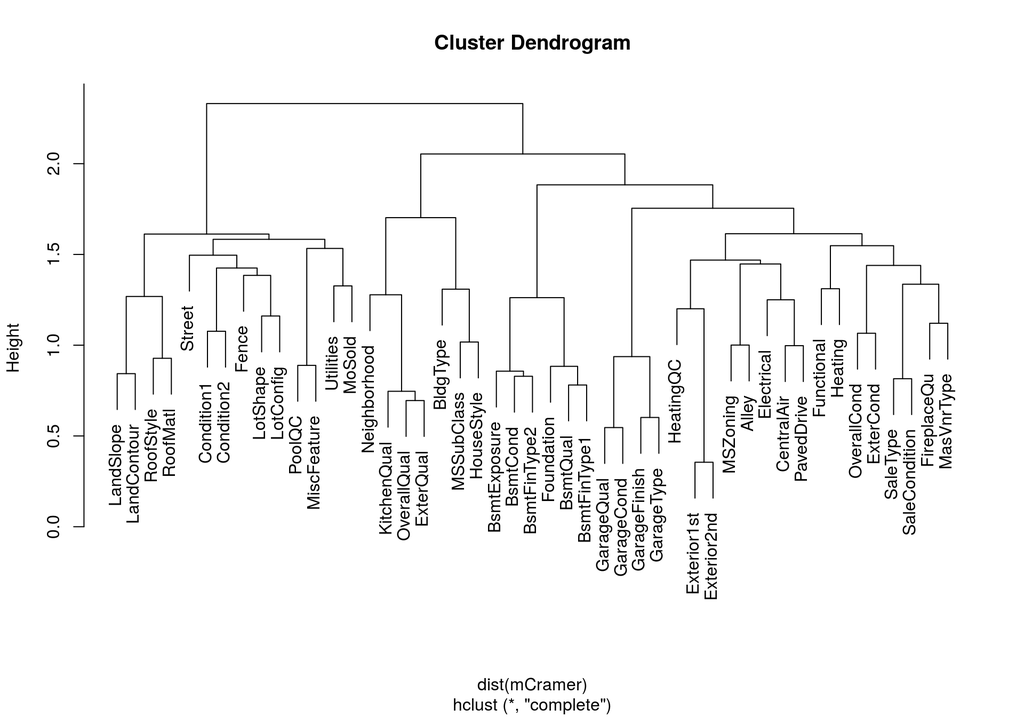

```r
corrClust <- hclust(dist(mCramer))
plot(corrClust)
```

### 3.2.3 Correlation to Target

For all categorical features the Kruskal-Wallis $\chi^2$ statistic to the target *SalePrice* is calculated. Results are ordered by the $\chi^2$ value. The color labels the feature type, nominal or ordinal.

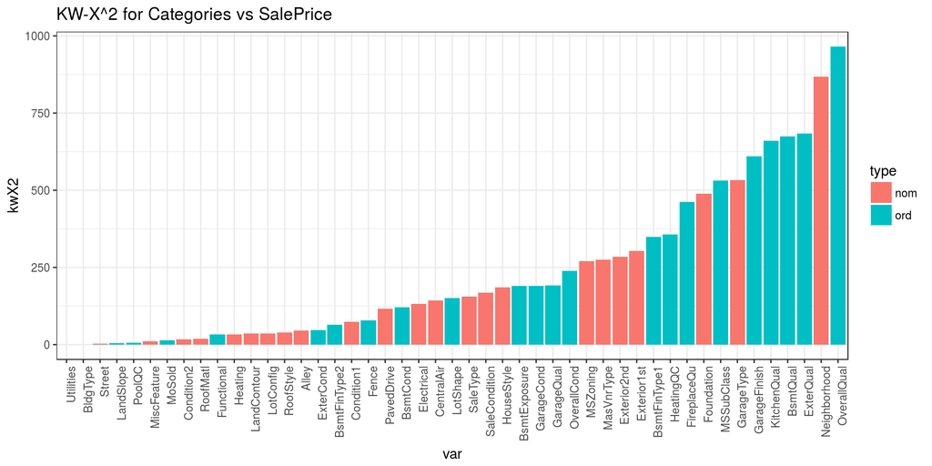

```r
kwX2 <- vapply(
  c(ordVars, nomVars),
  function(j) { kruskal.test(train$SalePrice, train[[j]])$statistic },
  numeric(1)
)
df <- data.frame(
  var = factor(c(ordVars, nomVars),
               levels = c(ordVars, nomVars)[order(kwX2)]),
  kwX2 = kwX2,
  type = rep(c("ord", "nom"), c(length(ordVars), length(nomVars)))
)
ggplot(df, aes(x = var, y = kwX2, fill = type)) +
  geom_bar(stat = "identity") +
  theme_bw() +
  theme(axis.text.x = element_text(angle = 90, hjust = 1)) +
  ggtitle("KW-X^2 for Categories vs SalePrice")
```